# RVenn: An R package for set operations on multiple sets

Turgut Yigit Akyol

2019-07-18

## Introduction

This tutorial shows how to use `RVenn`, a package for dealing with multiple sets. The base R functions (`intersect`, `union` and `setdiff`) only work with two sets. `%>%` can be used from `magrittr` but, for many sets this can be tedious. `reduce` function from `purrr` package also provides a solution, which is the function that is used for set operations in this package. The functions `overlap`, `unite` and `discern` abstract away the details, so one can just construct the universe and choose the sets to operate by index or set name. Further, by using `ggvenn` Venn diagram can be drawn for 2-3 sets. As you can notice from the name of the function, `ggvenn` is based on `ggplot2`, so it is a neat way to show the relationship among a reduced number sets. For many sets, it is much better to use [UpSet](http://caleydo.org/tools/upset/) or `setmap` function provided within this package. Finally, by using `enrichment_test` function, the p-value of an overlap between two sets can be calculated. Here, the usage of all these functions will be shown.

## Creating toy data

This chunk of code will create 10 sets with sizes ranging from 5 to 25.

```r
library(purrr)
library(RVenn)
library(ggplot2)
```

```r
set.seed(42)
toy = map(sample(5:25, replace = TRUE, size = 10),
          function(x) sample(letters, size = x))
toy[1:3]  # First 3 of the sets.
```

```
#> [[1]]
#>  [1] "l" "r" "w" "f" "k" "t" "u" "c" "i" "j" "o" "s" "n" "m" "a" "x" "d"
#> [18] "y" "q" "v" "e" "g" "b" "p"
#>
#> [[2]]
#>  [1] "a" "u" "z" "e" "t" "m" "h" "i" "x" "q" "g" "o" "y" "s" "l" "p" "d"
#> [18] "j" "n" "f" "r" "v" "c" "k"
#>
#> [[3]]
#>  [1] "g" "m" "q" "w" "x" "l" "v" "d" "e" "o" "u"
```

### Construct the Venn object

```r
toy = Venn(toy)
```

## Set operations

### Intersection

Intersection of all sets:

```r
overlap(toy)
```

```
#> [1] "g"
```

Intersection of selected sets (chosen with set names or indices, respectively):

```r
overlap(toy, c("Set_1", "Set_2", "Set_5", "Set_8"))
```

```
#> [1] "t" "o" "d" "v" "e" "g"
```

```r
overlap(toy, c(1, 2, 5, 8))
```

```
#> [1] "t" "o" "d" "v" "e" "g"
```

### Pairwise intersections

```r
overlap_pairs(toy, slice = 1:4)
```

```
#> $Set_1...Set_2
#>  [1] "l" "r" "f" "k" "t" "u" "c" "i" "j" "o" "s" "n" "m" "a" "x" "d" "y"
#> [18] "q" "v" "e" "g" "p"
#>
#> $Set_1...Set_3
#>  [1] "l" "w" "u" "o" "m" "x" "d" "q" "v" "e" "g"
#>
#> $Set_1...Set_4
#>  [1] "l" "w" "f" "k" "t" "u" "c" "i" "o" "s" "n" "a" "x" "d" "y" "q" "e"
#> [18] "g" "b" "p"
#>
#> $Set_2...Set_3
#>  [1] "u" "e" "m" "x" "q" "g" "o" "l" "d" "v"
#>
#> $Set_2...Set_4
#>  [1] "a" "u" "z" "e" "t" "h" "i" "x" "q" "g" "o" "y" "s" "l" "p" "d" "n"
#> [18] "f" "c" "k"
#>
#> $Set_3...Set_4
#> [1] "g" "q" "w" "x" "l" "d" "e" "o" "u"
```

### Union

Union of all sets:

```r
unite(toy)
```

```
#>  [1] "l" "r" "w" "f" "k" "t" "u" "c" "i" "j" "o" "s" "n" "m" "a" "x" "d"
#> [18] "y" "q" "v" "e" "g" "b" "p" "z" "h"
```

Union of selected sets (chosen with set names or indices, respectively):

```r
unite(toy, c("Set_3", "Set_8"))
```

```
#>  [1] "g" "m" "q" "w" "x" "l" "v" "d" "e" "o" "u" "t"
```

```r
unite(toy, c(3, 8))
```

```
#>  [1] "g" "m" "q" "w" "x" "l" "v" "d" "e" "o" "u" "t"
```

### Pairwise unions

```r
unite_pairs(toy, slice = 1:4)
```

```
#> $Set_1...Set_2
#>  [1] "l" "r" "w" "f" "k" "t" "u" "c" "i" "j" "o" "s" "n" "m" "a" "x" "d"
#> [18] "y" "q" "v" "e" "g" "b" "p" "z" "h"
#>
#> $Set_1...Set_3
#>  [1] "l" "r" "w" "f" "k" "t" "u" "c" "i" "j" "o" "s" "n" "m" "a" "x" "d"
#> [18] "y" "q" "v" "e" "g" "b" "p"
#>
#> $Set_1...Set_4
#>  [1] "l" "r" "w" "f" "k" "t" "u" "c" "i" "j" "o" "s" "n" "m" "a" "x" "d"
#> [18] "y" "q" "v" "e" "g" "b" "p" "z" "h"
#>
#> $Set_2...Set_3
#>  [1] "a" "u" "z" "e" "t" "m" "h" "i" "x" "q" "g" "o" "y" "s" "l" "p" "d"
#> [18] "j" "n" "f" "r" "v" "c" "k" "w"
#>
#> $Set_2...Set_4
#>  [1] "a" "u" "z" "e" "t" "m" "h" "i" "x" "q" "g" "o" "y" "s" "l" "p" "d"
#> [18] "j" "n" "f" "r" "v" "c" "k" "b" "w"
#>
#> $Set_3...Set_4
#>  [1] "g" "m" "q" "w" "x" "l" "v" "d" "e" "o" "u" "b" "k" "a" "z" "i" "s"
#> [18] "c" "h" "t" "f" "n" "p" "y"
```

### Set difference

```r
discern(toy, 1, 8)
```

```
#>  [1] "l" "r" "w" "f" "k" "c" "i" "j" "s" "n" "m" "a" "x" "y" "q" "b" "p"
```

```r
discern(toy, "Set_1", "Set_8")
```

```
#>  [1] "l" "r" "w" "f" "k" "c" "i" "j" "s" "n" "m" "a" "x" "y" "q" "b" "p"
```

```r
discern(toy, c(3, 4), c(7, 8))
```

```
#> [1] "q" "k" "c" "h"
```

### Pairwise differences

```r
discern_pairs(toy, slice = 1:4)
```

```
#> $Set_1...Set_2
#> [1] "w" "b"
#>
#> $Set_1...Set_3
#>  [1] "r" "f" "k" "t" "c" "i" "j" "s" "n" "a" "y" "b" "p"
#>
#> $Set_1...Set_4
#> [1] "r" "j" "m" "v"
#>
#> $Set_2...Set_3
#>  [1] "a" "z" "t" "h" "i" "y" "s" "p" "j" "n" "f" "r" "c" "k"
#>
#> $Set_2...Set_4
#> [1] "m" "j" "r" "v"
#>
#> $Set_3...Set_4
#> [1] "m" "v"
#>
#> $Set_2...Set_1
#> [1] "z" "h"
#>
#> $Set_3...Set_1
#> character(0)
#>
#> $Set_4...Set_1
#> [1] "z" "h"
#>
#> $Set_3...Set_2
#> [1] "w"
#>
#> $Set_4...Set_2
#> [1] "b" "w"
#>
#> $Set_4...Set_3
#>  [1] "b" "k" "a" "z" "i" "s" "c" "h" "t" "f" "n" "p" "y"
```

## Venn Diagram

For two sets:

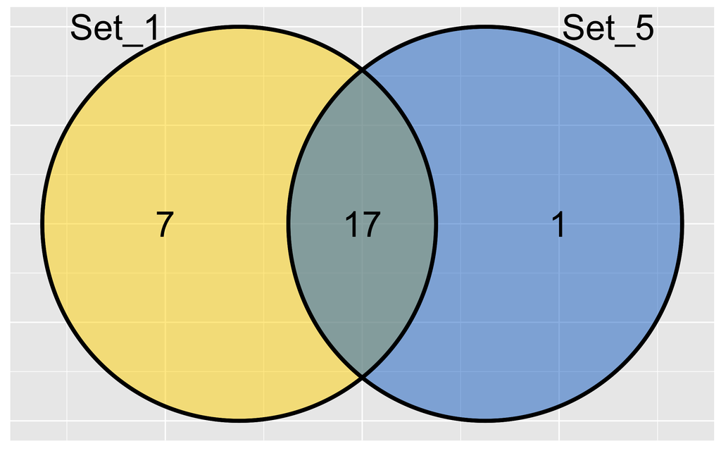

```r
ggvenn(toy, slice = c(1, 5))
```

For three sets:

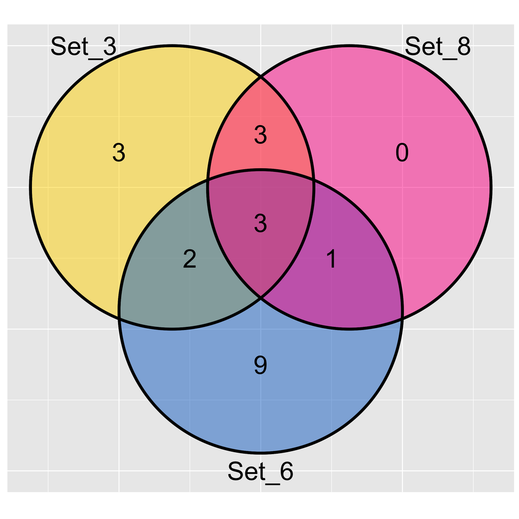

```r
ggvenn(toy, slice = c(3, 6, 8))
```

## Heatmap

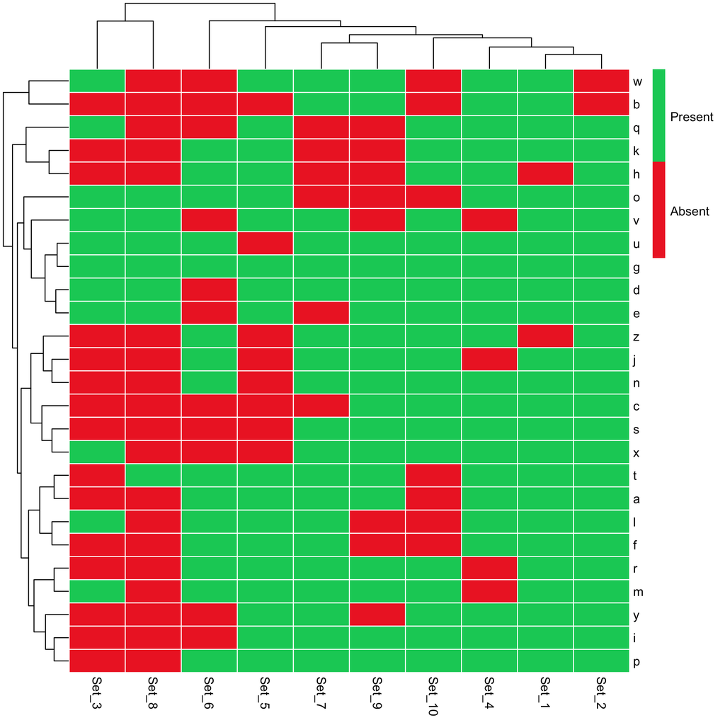

```r
setmap(toy)
```

Without clustering

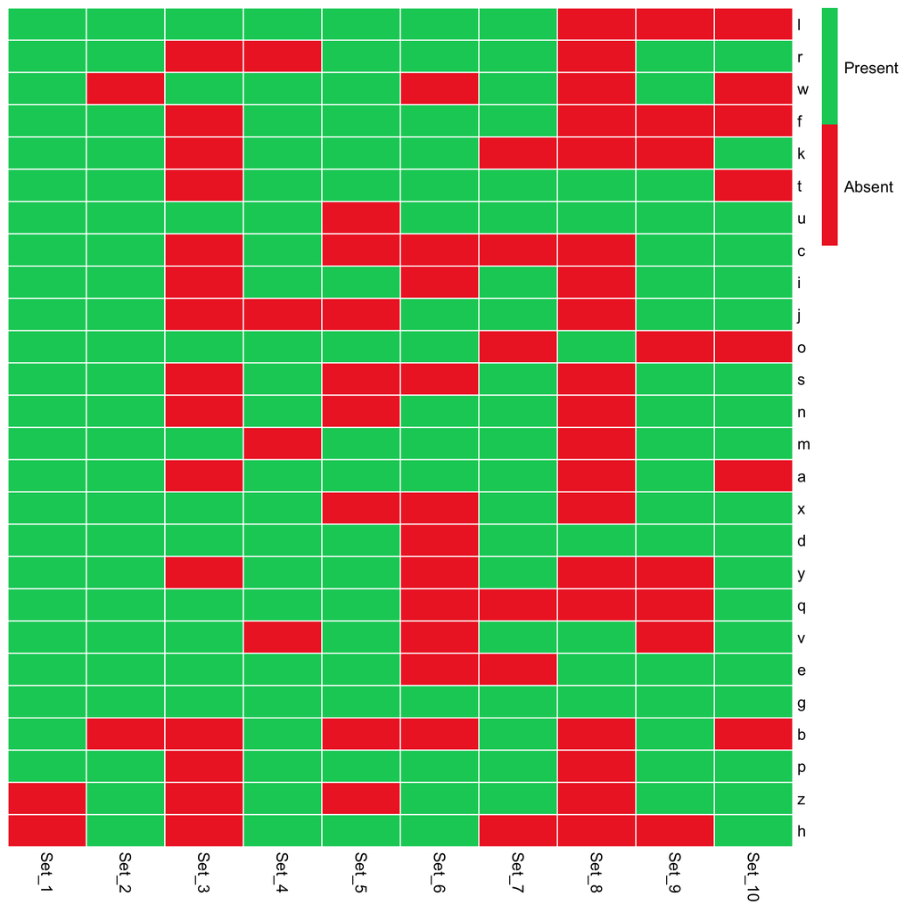

```r
setmap(toy, element_clustering = FALSE, set_clustering = FALSE)
```

## Enrichment test

```r
er = enrichment_test(toy, 6, 7)
er$Significance
```

```
#> [1] 0.4981
```

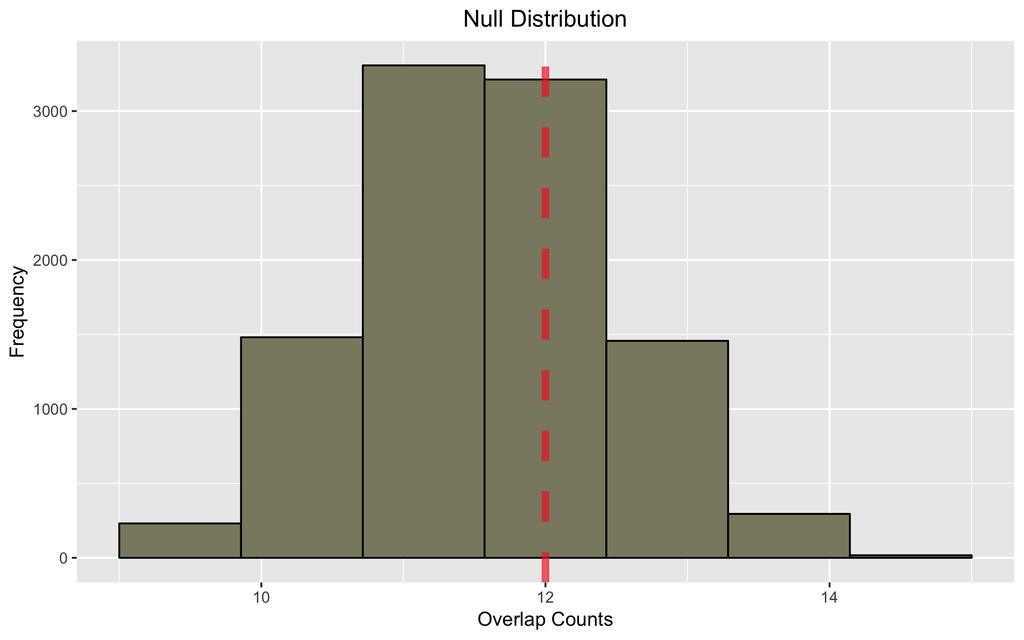

```r
qplot(er$Overlap_Counts, geom = "blank") +
  geom_histogram(fill = "lemonchiffon4", bins = 8, color = "black") +
  geom_vline(xintercept = length(overlap(toy, c(6, 7))), color = "firebrick2",
             size = 2, linetype = "dashed", alpha = 0.7) +
  ggtitle("Null Distribution") +
  theme(plot.title = element_text(hjust = 0.5)) +
  scale_x_continuous(name = "Overlap Counts") +
  scale_y_continuous(name = "Frequency")
```

The test above, of course, is not very meaningful as we randomly created the sets; therefore, we get a high p-value. However, when you are working with actual data, e.g. to check if a motif is enriched in the promoter regions of the genes in a gene set, you can use this test. In that case, `set1` will be the gene set of interest, `set2` will be the all the genes that the motif is found in the genome and `univ` will be all the genes of a genome.